# Analisis Calidad de Vino

Ing. Ana Munoz

```r
BDwine = read.csv("C:/Users/dayalaga/Downloads/Control 2 - Ana Muñoz #ggplot/winequality-white.csv", sep = ";", header = TRUE)
library(ggplot2)
library(dplyr)
library(corrplot)
```

# Informacion General - Calidad de Vino

## Conociendo mi base de datos

### Principales Caracteristicas

La BD brindada consta de las siguientes caraceristicas:

```r
summary(BDwine)
```

```
##  fixed.acidity    volatile.acidity  citric.acid     residual.sugar
##  Min.   : 3.800   Min.   :0.0800   Min.   :0.0000   Min.   : 0.600
##  1st Qu.: 6.300   1st Qu.:0.2100   1st Qu.:0.2700   1st Qu.: 1.700
##  Median : 6.800   Median :0.2600   Median :0.3200   Median : 5.200
##  Mean   : 6.855   Mean   :0.2782   Mean   :0.3342   Mean   : 6.391
##  3rd Qu.: 7.300   3rd Qu.:0.3200   3rd Qu.:0.3900   3rd Qu.: 9.900
##  Max.   :14.200   Max.   :1.1000   Max.   :1.6600   Max.   :65.800
##    chlorides       free.sulfur.dioxide total.sulfur.dioxide
##  Min.   :0.00900   Min.   :  2.00      Min.   :  9.0
##  1st Qu.:0.03600   1st Qu.: 23.00      1st Qu.:108.0
##  Median :0.04300   Median : 34.00      Median :134.0
##  Mean   :0.04577   Mean   : 35.31      Mean   :138.4
##  3rd Qu.:0.05000   3rd Qu.: 46.00      3rd Qu.:167.0
##  Max.   :0.34600   Max.   :289.00      Max.   :440.0
##     density             pH          sulphates         alcohol
##  Min.   :0.9871   Min.   :2.720   Min.   :0.2200   Min.   : 8.00
##  1st Qu.:0.9917   1st Qu.:3.090   1st Qu.:0.4100   1st Qu.: 9.50
##  Median :0.9937   Median :3.180   Median :0.4700   Median :10.40
##  Mean   :0.9940   Mean   :3.188   Mean   :0.4898   Mean   :10.51
##  3rd Qu.:0.9961   3rd Qu.:3.280   3rd Qu.:0.5500   3rd Qu.:11.40
##  Max.   :1.0390   Max.   :3.820   Max.   :1.0800   Max.   :14.20
##     quality
##  Min.   :3.000
##  1st Qu.:5.000
##  Median :6.000
##  Mean   :5.878
##  3rd Qu.:6.000
##  Max.   :9.000
```

```r
str(BDwine)
```

```
## 'data.frame':    4898 obs. of  12 variables:
##  $ fixed.acidity       : num  7 6.3 8.1 7.2 7.2 8.1 6.2 7 6.3 8.1 ...
##  $ volatile.acidity    : num  0.27 0.3 0.28 0.23 0.23 0.28 0.32 0.27 0.3 0.22 ...
##  $ citric.acid         : num  0.36 0.34 0.4 0.32 0.32 0.4 0.16 0.36 0.34 0.43 ...
##  $ residual.sugar      : num  20.7 1.6 6.9 8.5 8.5 6.9 7 20.7 1.6 1.5 ...
##  $ chlorides           : num  0.045 0.049 0.05 0.058 0.058 0.05 0.045 0.045 0.049 0.044 ...
##  $ free.sulfur.dioxide : num  45 14 30 47 47 30 30 45 14 28 ...
##  $ total.sulfur.dioxide: num  170 132 97 186 186 97 136 170 132 129 ...
##  $ density             : num  1.001 0.994 0.995 0.996 0.996 ...
##  $ pH                  : num  3 3.3 3.26 3.19 3.19 3.26 3.18 3 3.3 3.22 ...
##  $ sulphates           : num  0.45 0.49 0.44 0.4 0.4 0.44 0.47 0.45 0.49 0.45 ...
##  $ alcohol             : num  8.8 9.5 10.1 9.9 9.9 10.1 9.6 8.8 9.5 11 ...
##  $ quality             : int  6 6 6 6 6 6 6 6 6 6 ...
```

Se puede apreciar que la BD no contempla valores faltantes o desconocidos, por lo que se prosigue a graficar para el análisis.

### Histograma de la BD según su calidad

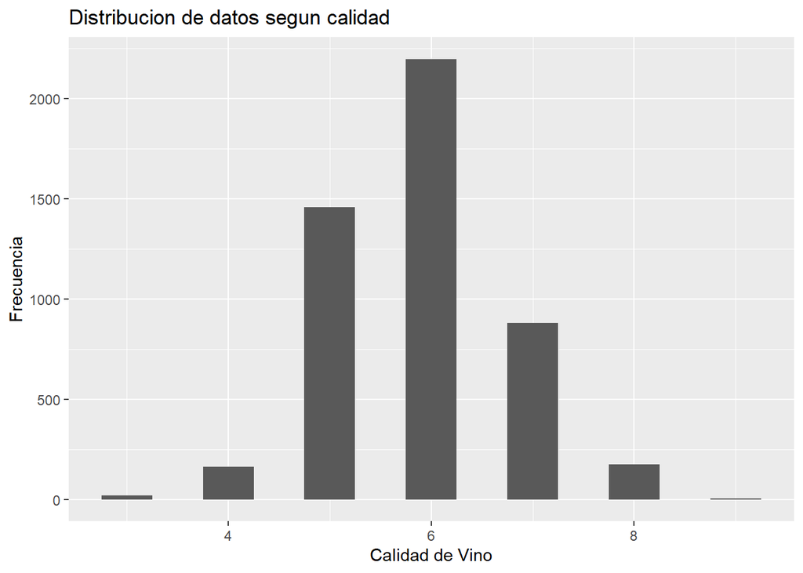

```r
ggplot(BDwine, aes(x = BDwine$quality))+
  geom_histogram(binwidth = 0.5) +
  xlab("Calidad de Vino") + ylab ("Frecuencia") +
  ggtitle("Distribucion de datos segun calidad")
```

## Correlación entre las variables de la BD

(tab content) Puedo ver la relacion de las variables entre ellas. Se destaca la relacion de:

- Calidad Vs Alcohol
- Densidad Vs Alcohol
- Densidad VS Azucar Residual
- Calidad VS Acidez Fija
- Calidad Vs Acidez Volatil

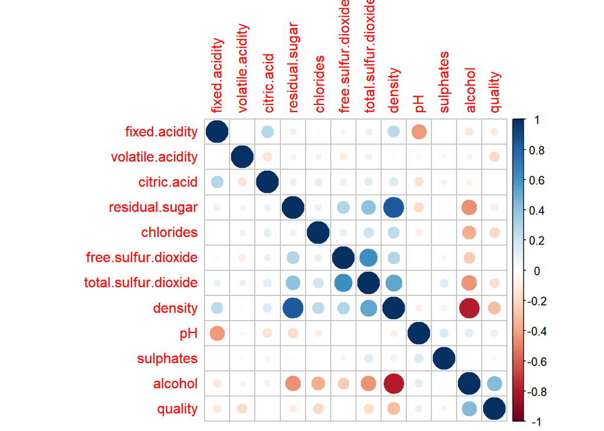

```r
mat.cor = cor(BDwine[-13])
corrplot(mat.cor, method = "circle")
```

# Reclasificacion de Datos

Para un mejor estudio de los datos se agruparán en tres principales grupos a la calidad de vino.

## Nueva Varible Classify

```r
BDwine$Classify = ifelse(BDwine$quality >= 8, "Alta",
  ifelse(BDwine$quality <= 3, "Baja","Media"))
summary(BDwine$Classify)
```

```
##    Length     Class      Mode
##      4898 character character
```

```r
str(BDwine$Classify)
```

```
##  chr [1:4898] "Media" "Media" "Media" "Media" "Media" "Media" "Media" ...
```

### Analisis por Calidad Clasificación

Se realiza un analisis de las correlaciones de Densidad y Alcohol según su clasificación de calidad.

- Podemos deducir que los vino con calidad más alta tienen en su mayoria un alto grado de alcohol y por lo tanto menor densidad
- La densidad y el grado de alcohol de los vinos de calidad Baja son muy dispersos por lo que no se puede realizar una deducción
- Los vino con calidad Media tienen datos picos fuera de la media

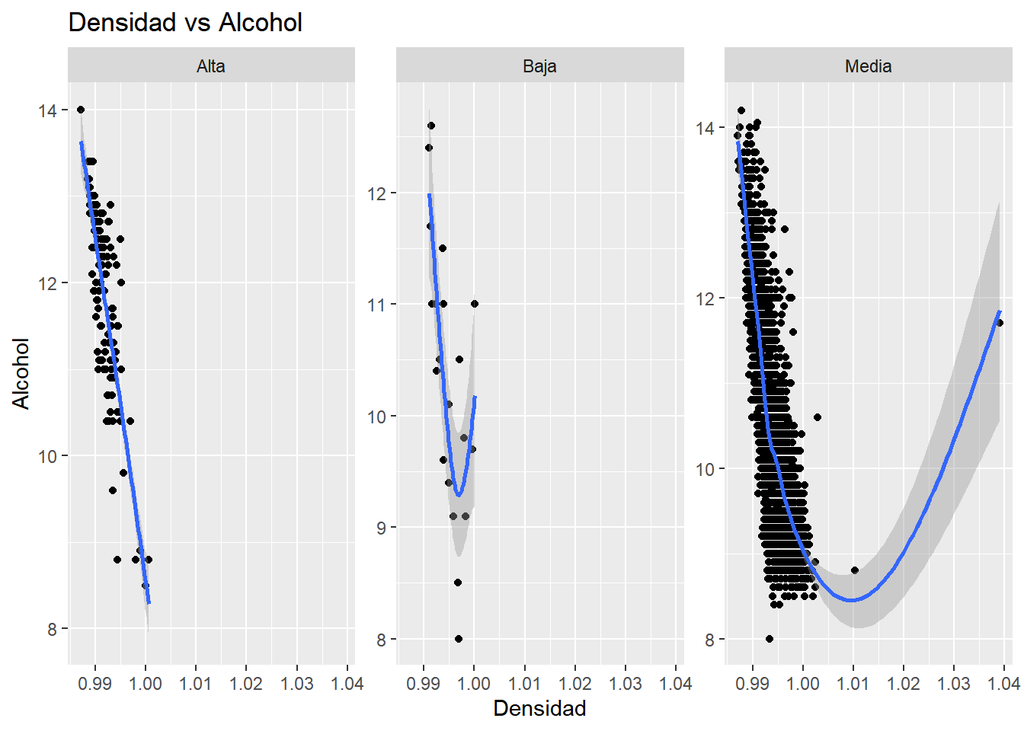

```r
ggplot(BDwine, aes(x = BDwine$density, y = BDwine$alcohol)) +
  xlab("Densidad") + ylab ("Alcohol") +
  ggtitle("Densidad vs Alcohol") +
  geom_point() +
  facet_wrap(~ BDwine$Classify, scale = "free_y")+
  geom_smooth()
```

## Partición de la BD

Para un mejor analisis segmentado, se separa la BD en tres Dataframe

```r
BDwine_splitted = split(BDwine, BDwine$Classify)

BDwine_Alta = BDwine_splitted$Alta
BDwine_Baja = BDwine_splitted$Baja
BDwine_Media = BDwine_splitted$Media

summary(BDwine_Alta)
```

```
##  fixed.acidity   volatile.acidity  citric.acid     residual.sugar
##  Min.   :3.900   Min.   :0.120    Min.   :0.0400   Min.   : 0.800
##  1st Qu.:6.200   1st Qu.:0.200    1st Qu.:0.2800   1st Qu.: 2.075
##  Median :6.800   Median :0.260    Median :0.3200   Median : 4.300
##  Mean   :6.678   Mean   :0.278    Mean   :0.3282   Mean   : 5.628
##  3rd Qu.:7.300   3rd Qu.:0.330    3rd Qu.:0.3600   3rd Qu.: 8.150
##  Max.   :9.100   Max.   :0.660    Max.   :0.7400   Max.   :14.800
##    chlorides       free.sulfur.dioxide total.sulfur.dioxide
##  Min.   :0.01400   Min.   :  6.00      Min.   : 59.0
##  1st Qu.:0.03000   1st Qu.: 28.00      1st Qu.:102.8
##  Median :0.03550   Median : 34.50      Median :122.0
##  Mean   :0.03801   Mean   : 36.63      Mean   :125.9
##  3rd Qu.:0.04400   3rd Qu.: 44.25      3rd Qu.:148.5
##  Max.   :0.12100   Max.   :105.00      Max.   :212.5
##     density             pH          sulphates         alcohol
##  Min.   :0.9871   Min.   :2.940   Min.   :0.2500   Min.   : 8.50
##  1st Qu.:0.9903   1st Qu.:3.127   1st Qu.:0.3800   1st Qu.:11.00
##  Median :0.9916   Median :3.230   Median :0.4600   Median :12.00
##  Mean   :0.9922   Mean   :3.221   Mean   :0.4857   Mean   :11.65
##  3rd Qu.:0.9935   3rd Qu.:3.330   3rd Qu.:0.5825   3rd Qu.:12.60
##  Max.   :1.0006   Max.   :3.590   Max.   :0.9500   Max.   :14.00
##     quality        Classify
##  Min.   :8.000   Length:180
##  1st Qu.:8.000   Class :character
##  Median :8.000   Mode  :character
##  Mean   :8.028
##  3rd Qu.:8.000
##  Max.   :9.000
```

```r
summary(BDwine_Media)
```

```
##  fixed.acidity    volatile.acidity  citric.acid     residual.sugar
##  Min.   : 3.800   Min.   :0.080    Min.   :0.0000   Min.   : 0.600
##  1st Qu.: 6.300   1st Qu.:0.210    1st Qu.:0.2700   1st Qu.: 1.700
##  Median : 6.800   Median :0.260    Median :0.3200   Median : 5.200
##  Mean   : 6.858   Mean   :0.278    Mean   :0.3344   Mean   : 6.421
##  3rd Qu.: 7.300   3rd Qu.:0.320    3rd Qu.:0.3900   3rd Qu.: 9.900
##  Max.   :14.200   Max.   :1.100    Max.   :1.6600   Max.   :65.800
##    chlorides       free.sulfur.dioxide total.sulfur.dioxide
##  Min.   :0.00900   Min.   :  2.00      Min.   :  9.0
##  1st Qu.:0.03600   1st Qu.: 23.00      1st Qu.:109.0
##  Median :0.04300   Median : 34.00      Median :135.0
##  Mean   :0.04603   Mean   : 35.18      Mean   :138.7
##  3rd Qu.:0.05000   3rd Qu.: 46.00      3rd Qu.:168.0
##  Max.   :0.34600   Max.   :138.50      Max.   :344.0
##     density             pH          sulphates         alcohol
##  Min.   :0.9871   Min.   :2.720   Min.   :0.2200   Min.   : 8.00
##  1st Qu.:0.9918   1st Qu.:3.080   1st Qu.:0.4100   1st Qu.: 9.40
##  Median :0.9938   Median :3.180   Median :0.4800   Median :10.30
##  Mean   :0.9941   Mean   :3.187   Mean   :0.4901   Mean   :10.47
##  3rd Qu.:0.9962   3rd Qu.:3.280   3rd Qu.:0.5500   3rd Qu.:11.30
##  Max.   :1.0390   Max.   :3.820   Max.   :1.0800   Max.   :14.20
##     quality        Classify
##  Min.   :4.000   Length:4698
##  1st Qu.:5.000   Class :character
##  Median :6.000   Mode  :character
##  Mean   :5.808
##  3rd Qu.:6.000
##  Max.   :7.000
```

```r
summary(BDwine_Baja)
```

```
##  fixed.acidity    volatile.acidity  citric.acid     residual.sugar
##  Min.   : 4.200   Min.   :0.1700   Min.   :0.2100   Min.   : 0.700
##  1st Qu.: 6.575   1st Qu.:0.2375   1st Qu.:0.2575   1st Qu.: 1.587
##  Median : 7.300   Median :0.2600   Median :0.3450   Median : 4.600
##  Mean   : 7.600   Mean   :0.3332   Mean   :0.3360   Mean   : 6.393
##  3rd Qu.: 8.525   3rd Qu.:0.4125   3rd Qu.:0.3850   3rd Qu.:10.700
##  Max.   :11.800   Max.   :0.6400   Max.   :0.4700   Max.   :16.200
##    chlorides       free.sulfur.dioxide total.sulfur.dioxide
##  Min.   :0.02200   Min.   :  5.00      Min.   : 19.0
##  1st Qu.:0.03625   1st Qu.: 13.25      1st Qu.:105.8
##  Median :0.04100   Median : 33.50      Median :159.5
##  Mean   :0.05430   Mean   : 53.33      Mean   :170.6
##  3rd Qu.:0.05400   3rd Qu.: 47.50      3rd Qu.:210.0
##  Max.   :0.24400   Max.   :289.00      Max.   :440.0
##     density             pH          sulphates         alcohol
##  Min.   :0.9911   Min.   :2.870   Min.   :0.2800   Min.   : 8.00
##  1st Qu.:0.9925   1st Qu.:3.035   1st Qu.:0.3800   1st Qu.: 9.55
##  Median :0.9944   Median :3.215   Median :0.4400   Median :10.45
##  Mean   :0.9949   Mean   :3.188   Mean   :0.4745   Mean   :10.35
##  3rd Qu.:0.9969   3rd Qu.:3.325   3rd Qu.:0.5425   3rd Qu.:11.00
##  Max.   :1.0001   Max.   :3.550   Max.   :0.7400   Max.   :12.60
##     quality    Classify
##  Min.   :3   Length:20
##  1st Qu.:3   Class :character
##  Median :3   Mode  :character
##  Mean   :3
##  3rd Qu.:3
##  Max.   :3
```

# Analisis por variable

## Calidad Alta

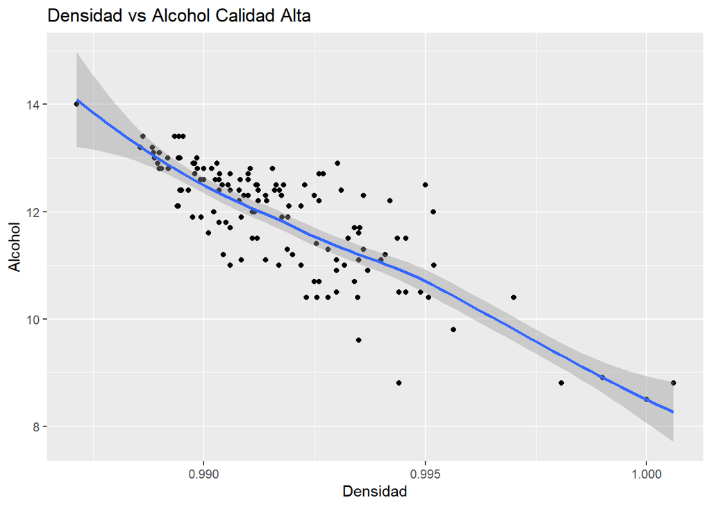

```r
ggplot(BDwine_Alta, aes(x = BDwine_Alta$density, y = BDwine_Alta$alcohol)) +
  xlab("Densidad") + ylab ("Alcohol") +
  ggtitle("Densidad vs Alcohol Calidad Alta") +
  geom_point() +
  geom_smooth()
```

## Calidad Baja

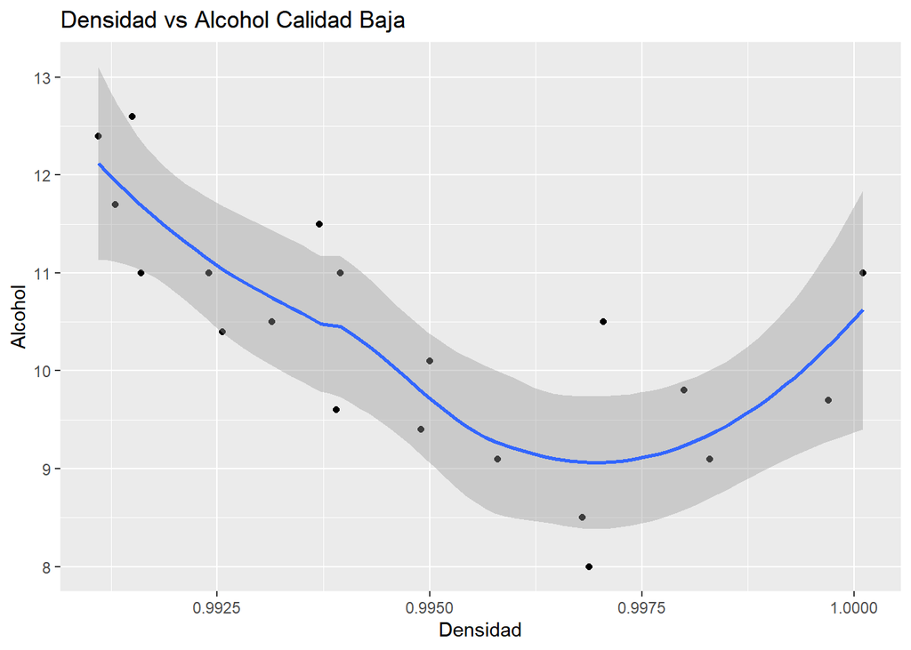

```r
ggplot(BDwine_Baja, aes(x = BDwine_Baja$density, y = BDwine_Baja$alcohol)) +
  xlab("Densidad") + ylab ("Alcohol") +
  ggtitle("Densidad vs Alcohol Calidad Baja") +
  geom_point() +
  geom_smooth()
```

## Calidad Media

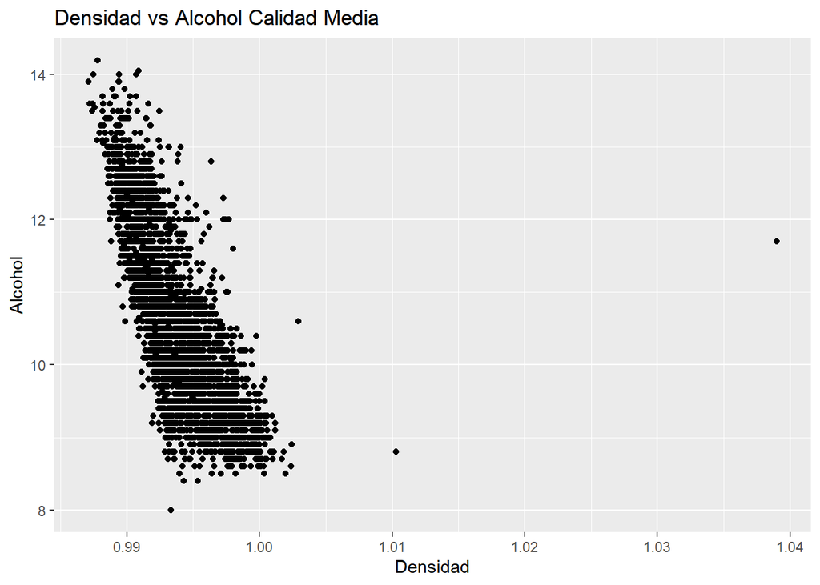

```r
ggplot(BDwine_Media, aes(x = BDwine_Media$density, y = BDwine_Media$alcohol)) +
  xlab("Densidad") + ylab ("Alcohol") +
  ggtitle("Densidad vs Alcohol Calidad Media") +
  geom_point()
```

# Relacion entre variables por Calidad

## Calidad vs Alcohol

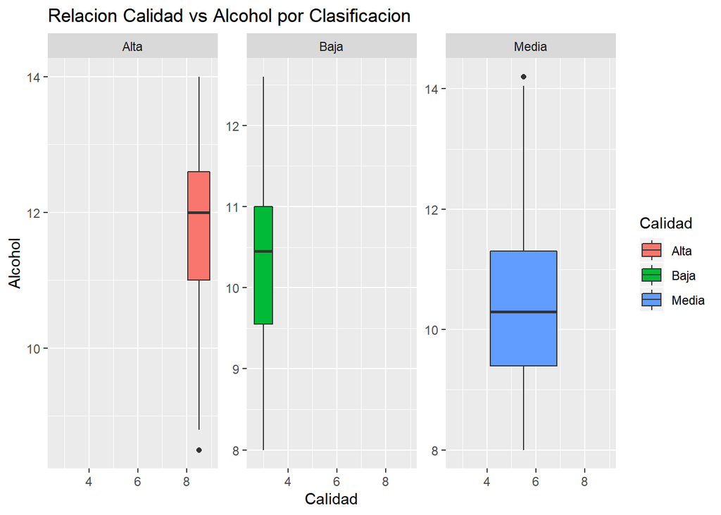

```r
ggplot(data = BDwine, aes(x = BDwine$quality, y = BDwine$alcohol)) +
  geom_boxplot(aes(fill = as.character(BDwine$Classify))) +
  facet_wrap(~ BDwine$Classify, scale = "free_y")+
  ylab("Alcohol") + xlab("Calidad")+
  guides(fill = guide_legend(title="Calidad"))+
  ggtitle("Relacion Calidad vs Alcohol por Clasificacion")
```

## Calidad vs Total Dioxido de Sulfuro

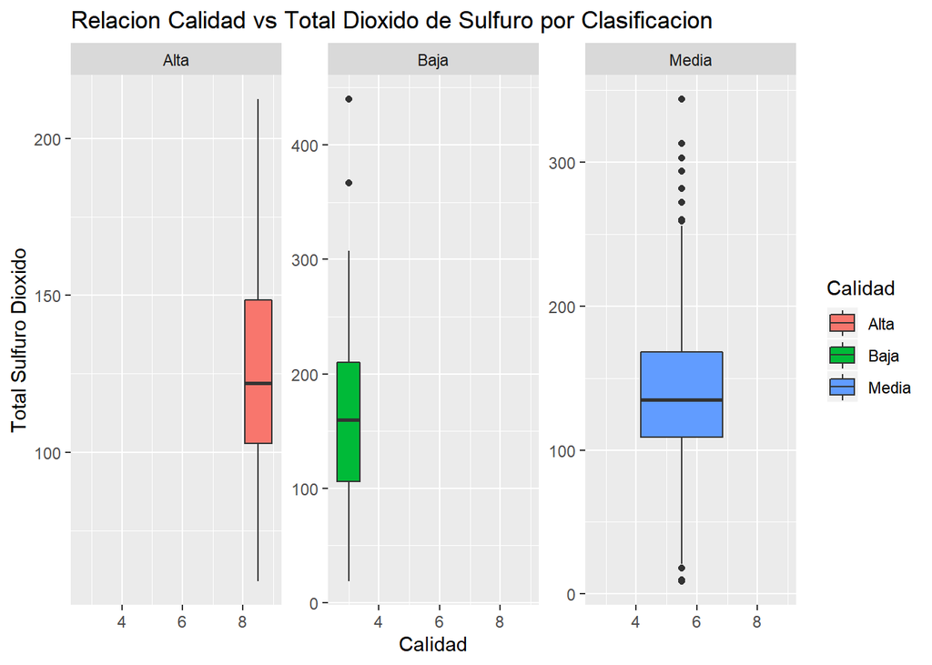

```r
ggplot(data = BDwine, aes(x = BDwine$quality, y = BDwine$total.sulfur.dioxide)) +
  geom_boxplot(aes(fill = as.character(BDwine$Classify))) +
  facet_wrap(~ BDwine$Classify, scale = "free_y") +
  ylab("Total Sulfuro Dioxido") + xlab("Calidad") +
  guides(fill = guide_legend(title="Calidad")) +
  ggtitle("Relacion Calidad vs Total Dioxido de Sulfuro por Clasificacion")
```

## Calidad vs Volatile Acidity

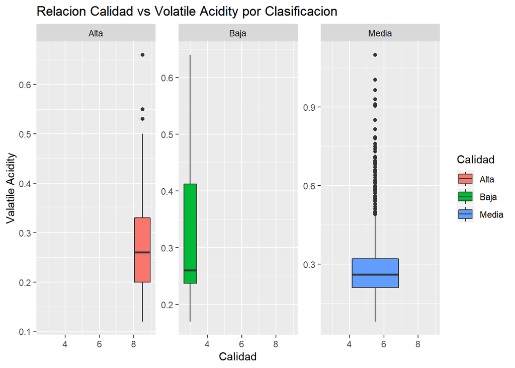

```r
ggplot(data = BDwine, aes(x = BDwine$quality, y = BDwine$volatile.acidity)) +
  geom_boxplot(aes(fill = as.character(BDwine$Classify))) +
  facet_wrap(~ BDwine$Classify, scale = "free_y") +
  ylab("Valatile Acidity") + xlab("Calidad") +
  guides(fill = guide_legend(title="Calidad")) +
  ggtitle("Relacion Calidad vs Volatile Acidity por Clasificacion")
```

## Calidad vs Fixed Acidity

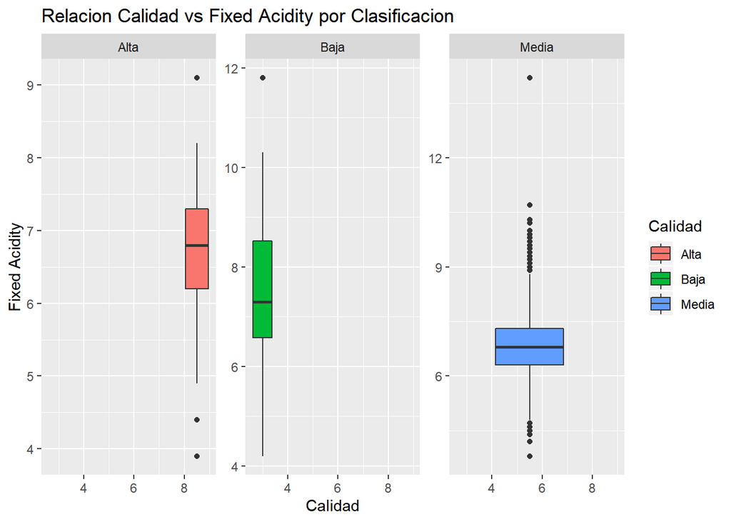

```r
ggplot(data = BDwine, aes(x = BDwine$quality, y = BDwine$fixed.acidity)) +
  geom_boxplot(aes(fill = as.character(BDwine$Classify))) +
  facet_wrap(~ BDwine$Classify, scale = "free_y") +
  ylab("Fixed Acidity") + xlab("Calidad") +
  guides(fill = guide_legend(title="Calidad")) +
  ggtitle("Relacion Calidad vs Fixed Acidity por Clasificacion")
```

# Analisis a fondo de la calidad Media

## Distribución de datos Calidad Media

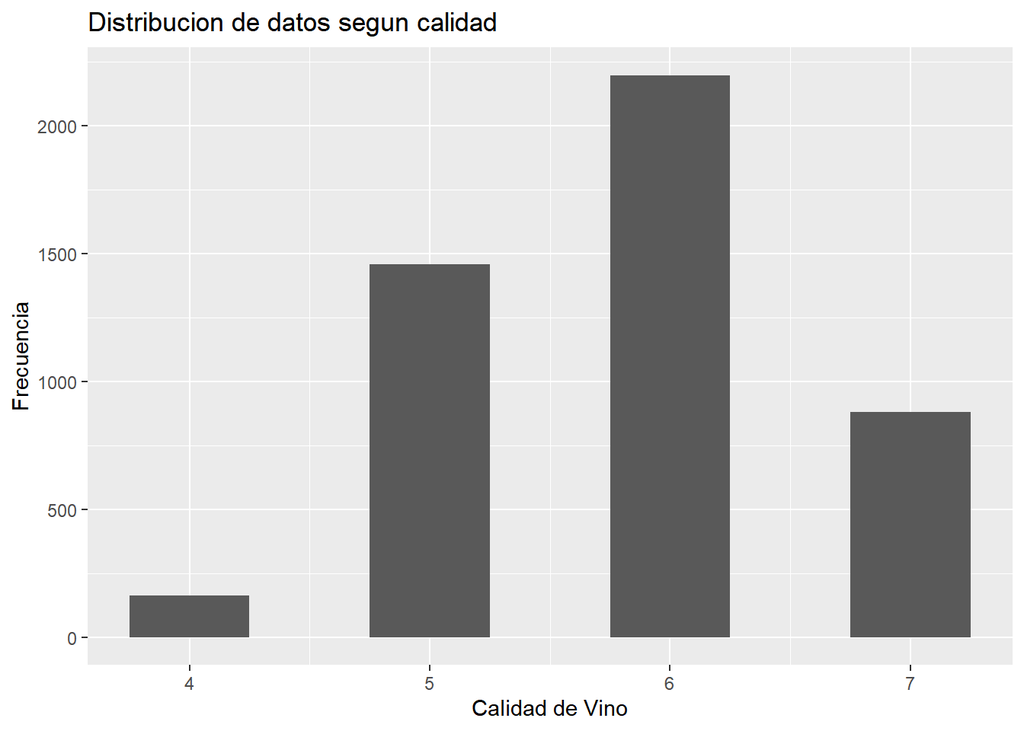

```r
ggplot(BDwine_Media, aes(x = BDwine_Media$quality))+
  geom_histogram(binwidth = 0.5) +
  xlab("Calidad de Vino") + ylab ("Frecuencia") +
  ggtitle("Distribucion de datos segun calidad")
```

## Relacion Densidad Vs Alcohol

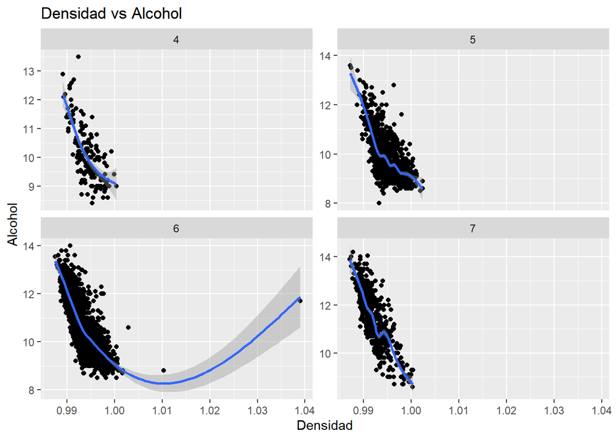

```r
ggplot(BDwine_Media, aes(x = BDwine_Media$density, y = BDwine_Media$alcohol)) +
  xlab("Densidad") + ylab ("Alcohol") +
  ggtitle("Densidad vs Alcohol") +
  geom_point() +
  facet_wrap(~ BDwine_Media$quality, scale = "free_y")+
  geom_smooth()
```

## Calidad vs Fixed Acidity

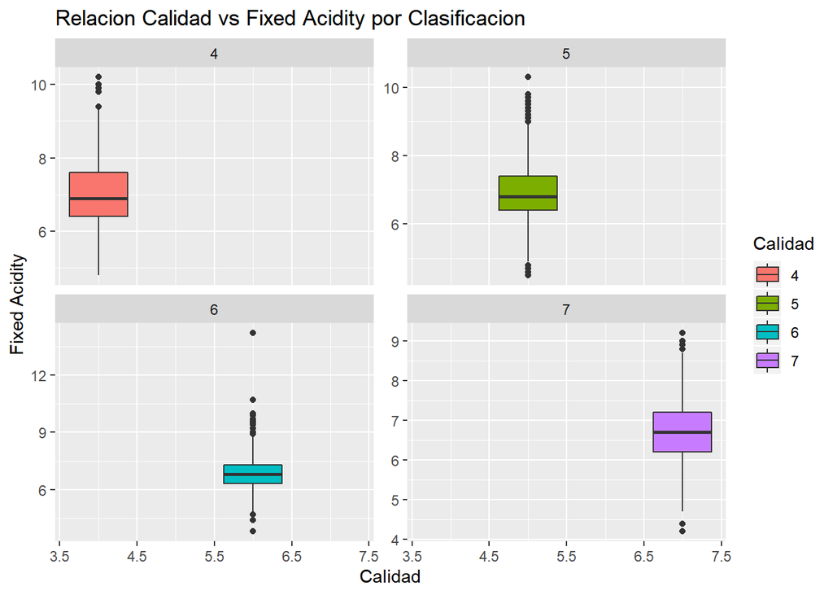

```r
ggplot(BDwine_Media, aes(x = BDwine_Media$quality, y = BDwine_Media$fixed.acidity)) +
  geom_boxplot(aes(fill = as.character(BDwine_Media$quality))) +
  facet_wrap(~ BDwine_Media$quality, scale = "free_y") +
  ylab("Fixed Acidity") + xlab("Calidad") +
  guides(fill = guide_legend(title="Calidad")) +
  ggtitle("Relacion Calidad vs Fixed Acidity por Clasificacion")
```